# Hongple

Joel Lee

#### 가설

```
초당 센서 값들의 각 조합에 대한 발생빈도를 계산, 발생 확률이 극히 낮거나 처음 발견되는 센서 값의 조합 발생시 이상패턴으로 정의, 탐지 가능하다.
```

#### 대상 데이터

- 단말사양 : AVN4 RC
- 국가 : 국내
- 차종 : UM
- 종류 : 주기적 운행 로그 (월 1회, vin별 1 trip, 1시간 이내 sample rate : 1 sec.)
- 테이블 : hkmc_tms.drv_rg_log_ps_avn4_rc
- 센서 : 227개
- 기간 : 6개월
- 클러스터 : 분석계 대화형
- 데이터베이스 : vcrm_6442267

#### 주기적 운행로그 수집주기 변경 vin 리스트

- 대상 : UM 400대 (2.0, 2.2 각 200대), AG 100대
- 변경 주기 : 월 1회  일 1회
- 기간 : 15년 1월 15일 ~ 3월 4일

#### 분석 프로세스

```
연속형센서 범주화 및 기초 통계 -> 이상 패턴 탐색 -> RO/DTC 연계 분석 -> 고장 조기 감지
```

##### 초기화 및 대화형 임팔라 접속

```
## character(0)
```

##### 1차 데이터 가공

- drv_rg_log_ps_avn4_rc_seq : 정기 운행로그에 주행별 시퀀스 추가(61,972,965건)

| 차종 | 레코드수(초당) |
| --- | --- |
| DM | 19110538 |
| UM | 36321553 |
| KH | 106191 |
| AG | 6432762 |
| TL | 1921 |

| 차종 | 주행 횟수 | 최초 주행시간 | 최종 주행시간 | 평균 주행(초수) |
| --- | --- | --- | --- | --- |
| DM | 12410 | 20141102020436 | 20150405185031 | 1534 |
| UM | 24863 | 20141001055302 | 20150405175643 | 1446 |
| KH | 78 | 20150111002956 | 20150405095542 | 1361 |
| AG | 4655 | 20141111093204 | 20150405104945 | 1379 |
| TL | 1 | 20150404181150 | 20150404181150 | 1921 |

| 차종 | 차량대수 ` |
| --- | --- |
| UM | 4904 |
| AG | 703 |
| DM | 5578 |
| TL | 1 |
| KH | 49 |

샘플 데이터 가져오기

```
## geom_smooth: method="auto" and size of largest group is >=1000, so using gam with formula: y ~ s(x, bs = "cs"). Use 'method = x' to change the smoothing method.
```

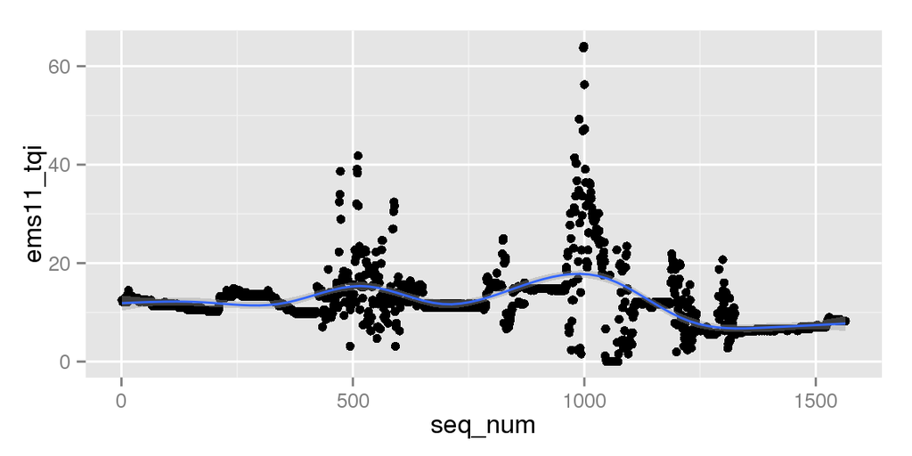

```r
df_sample = data.frame(sqlQuery( conn, "select * from vcrm_6442267.drv_rg_log_ps_avn4_rc_seq
                                 where vin = 'KNAPK81ABFA010727' and ignitiontime = '20141211074429'
                                 order by seq_num"))

#plot(df$seq_num, df$ems16_tqi_min, type="l", ylab="ems16_tqi_min", xlab="time(sec)")
qplot(seq_num, ems11_tqi, data = df_sample) + geom_smooth()
```

연속형 멀티센서 시계열 탐색

[figure not shown]

```r
# timeseries multiple plot
# par(pch=22, col="red") # plotting symbol and color
graphics.off()    # close graphics windows
# 20 of 227 plots on one page
par(mfrow=c(5, 4), mar = c(2, 2, 2, 1), oma = c(0, 0, 1, 0))
signals = names(df_sample)

for(i in 7:25){
    signal_ts <- df_sample[,i]
    plot.ts(signal_ts, type="l", main=signals[i])
    }
```

##### 2차 데이터 가공

- drv_rg_log_ps_avn4_rc_factor10 : 연속형 센서 범주화 (10개씩 쪼개기)
- 전체 센서들에 대한 조합의 빈도수가 높지 않아 불필요한 센서 제거해야함.
- engfrzfrm12 센서그룹 제외(NULL 만 들어있음)
- 주요 센서그룹 Null 비율

| 센서그룹 | 전체 NULL(건수) | 전체 NULL(비율) | UM NULL(건수) | UM NULL(비율) |
| --- | --- | --- | --- | --- |
| engfrzfrm12 | 61,972,965 | 100% | 36,321,553 | 100% |
| ems19 | 25,649,491 | 41.388194% | 0 | 0% |
| fatc11 | 25,650,803 | 41.3903111% | 1,312 | 0.0036122% |
| bat11 | 25,650,996 | 41.3906225% | 1,505 | 0.0041435% |
| cgw1 | 26,613,289 | 42.9433851% | 963,797 | 2.6535126% |

Checksum 센서 제외  
- ems19_cf_ems_checksumems9 - ems16_checksum - fatc11_cf_fatc_chksum - tcu11_cf_tcu_chksum1 - sas11_checksum - tcu12_cf_tcu_chksum - tcu13_cf_tcu_chksum3

##### 3차 데이터 가공

UM(Disel) 차종의 센서그룹별 센서조합의 통계를 구해서 센서별 특징을 파악한다.

#### 주요 영향요인(센서) 분석

#### EMS11(파워트레인계열)

|  | vars | n | mean | sd | median | trimmed | mad | min | max | range | skew | kurtosis | se |
| --- | --- | --- | --- | --- | --- | --- | --- | --- | --- | --- | --- | --- | --- |
| ems11_swi_igk | 1 | 1049.00 | 0.99 | 0.10 | 1.00 | 1.00 | 0.00 | 0.00 | 1.00 | 1.00 | -10.08 | 99.71 | 0.00 |
| ems11_f_n_eng | 2 | 1049.00 | 0.00 | 0.00 | 0.00 | 0.00 | 0.00 | 0.00 | 0.00 | 0.00 |  |  | 0.00 |
| ems11_ack_tcs | 3 | 1049.00 | 1.00 | 0.07 | 1.00 | 1.00 | 0.00 | 0.00 | 1.00 | 1.00 | -14.36 | 204.41 | 0.00 |
| ems11_puc_stat | 4 | 1049.00 | 0.05 | 0.22 | 0.00 | 0.00 | 0.00 | 0.00 | 1.00 | 1.00 | 4.10 | 14.81 | 0.01 |
| ems11_tq_cor_stat | 5 | 1049.00 | 0.00 | 0.00 | 0.00 | 0.00 | 0.00 | 0.00 | 0.00 | 0.00 |  |  | 0.00 |
| ems11_rly_ac | 6 | 1049.00 | 0.39 | 0.49 | 0.00 | 0.37 | 0.00 | 0.00 | 1.00 | 1.00 | 0.43 | -1.82 | 0.02 |
| ems11_f_sub_tqi | 7 | 1049.00 | 0.00 | 0.00 | 0.00 | 0.00 | 0.00 | 0.00 | 0.00 | 0.00 |  |  | 0.00 |
| ems11_tqi_acor | 8 | 1049.00 | 3.93 | 2.58 | 4.00 | 3.88 | 2.97 | 0.00 | 9.00 | 9.00 | 0.12 | -1.03 | 0.08 |
| ems11_n | 9 | 1049.00 | 1.06 | 0.72 | 1.00 | 1.08 | 1.48 | 0.00 | 3.00 | 3.00 | -0.08 | -1.02 | 0.02 |
| ems11_tqi | 10 | 1049.00 | 4.49 | 2.76 | 5.00 | 4.54 | 2.97 | 0.00 | 9.00 | 9.00 | -0.12 | -1.13 | 0.09 |
| ems11_tqfr | 11 | 1049.00 | 0.30 | 0.46 | 0.00 | 0.25 | 0.00 | 0.00 | 1.00 | 1.00 | 0.86 | -1.27 | 0.01 |
| ems11_vs | 12 | 1049.00 | 2.49 | 1.93 | 2.00 | 2.33 | 1.48 | 0.00 | 8.00 | 8.00 | 0.57 | -0.50 | 0.06 |
| ems11_ratio_tqi_bas_max_stnd | 13 | 1049.00 | 0.00 | 0.00 | 0.00 | 0.00 | 0.00 | 0.00 | 0.00 | 0.00 |  |  | 0.00 |
| cnt | 14 | 1049.00 | 33948.54 | 375693.06 | 10.00 | 459.60 | 13.34 | 1.00 | 10900873.00 | 10900872.00 | 24.70 | 681.93 | 11599.66 |
| id | 15 | 1049.00 | 525.00 | 302.96 | 525.00 | 525.00 | 388.44 | 1.00 | 1049.00 | 1048.00 | 0.00 | -1.20 | 9.35 |
| pct | 16 | 1049.00 | 0.00 | 0.01 | 0.00 | 0.00 | 0.00 | 0.00 | 0.31 | 0.31 | 24.70 | 681.93 | 0.00 |

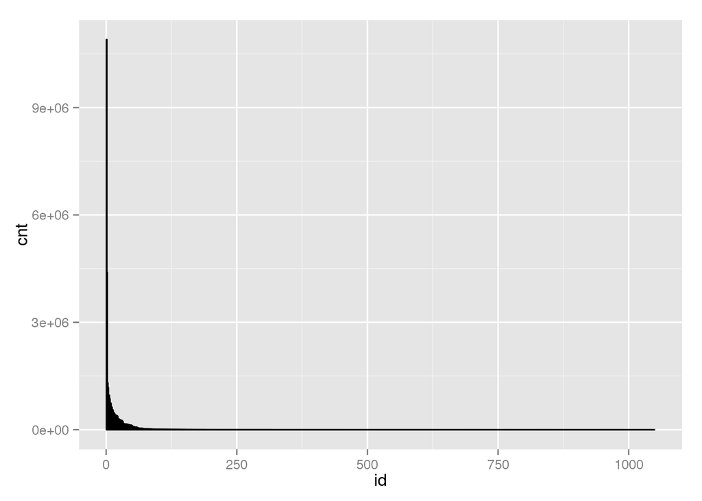

##### 주성분 분석(PCA)

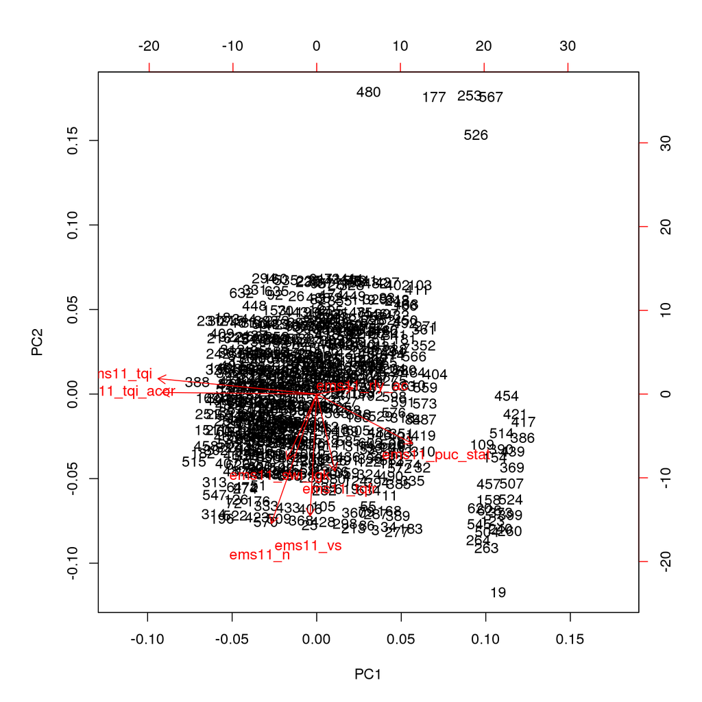

```r
#graphics.off()
#layout(matrix(c(1,2,3,4),2,2)) # optional 4 graphs/page
# 표준편차 0이 아닌 센서만 선별
test_df <- df_um_ems11[df_um_ems11$cnt<=30,c(1,4,6,8,9,10,11,12)]
#test_df <- df_um_ems11[,c(1,4,6,8,9,10,11,12)]
pca = prcomp(test_df, scale=TRUE)
#round(predict(pca),2)
#png("ems11_pca.png")
#plot(pca, type="lines")
biplot(pca)
```

```r
#dev.off()
```

ems11_tqi, ems11_tqi_acor, ems11_n가 주성분으로 보임 ems11_tqi, ems11_tqi_acor는 같은 성질을 가짐

##### 요인분석(Factor Analysis)

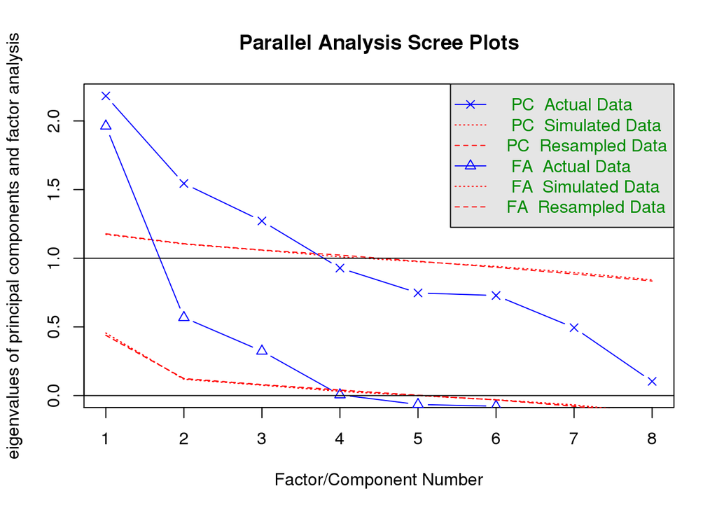

```
## Parallel analysis suggests that the number of factors =  3  and the number of components =  3
```

```r
fa.parallel(test_df)
```

```r
fit <- factanal(test_df, 3, rotation="promax")
fit
```

```
##
## Call:
## factanal(x = test_df, factors = 3, rotation = "promax")
##
## Uniquenesses:
##  ems11_swi_igk ems11_puc_stat   ems11_rly_ac ems11_tqi_acor        ems11_n
##          0.966          0.844          0.682          0.143          0.193
##      ems11_tqi     ems11_tqfr       ems11_vs
##          0.045          0.551          0.823
##
## Loadings:
##                Factor1 Factor2 Factor3
## ems11_swi_igk           0.160
## ems11_puc_stat -0.380
## ems11_rly_ac           -0.222   0.525
## ems11_tqi_acor  0.926           0.116
## ems11_n                 0.889
## ems11_tqi       0.960
## ems11_tqfr              0.184   0.639
## ems11_vs                0.420
##
##                Factor1 Factor2 Factor3
## SS loadings      1.939   1.087   0.712
## Proportion Var   0.242   0.136   0.089
## Cumulative Var   0.242   0.378   0.467
##
## Factor Correlations:
##         Factor1 Factor2 Factor3
## Factor1  1.0000 -0.0838 -0.1199
## Factor2 -0.0838  1.0000 -0.0227
## Factor3 -0.1199 -0.0227  1.0000
##
## Test of the hypothesis that 3 factors are sufficient.
## The chi square statistic is 9.22 on 7 degrees of freedom.
## The p-value is 0.237
```

Uniquenesses(유효성) : 0.5 이하이면 유효함.  
ems11_tqi_acor, ems11_n, ems11_tqi 가 유효하며 ems11_tqi와 ems11_tqi_acor는  
서로 비슷한 성질을 가지서 ems11_tqi을 제 1요인, ems11_n을 제2요인으로 선택한다.  
Factor Correlations를 보면 두 요인간에 별로 상관이 없음  
0.3이상이면 유의하지만 제3요인은 필요없을 듯..

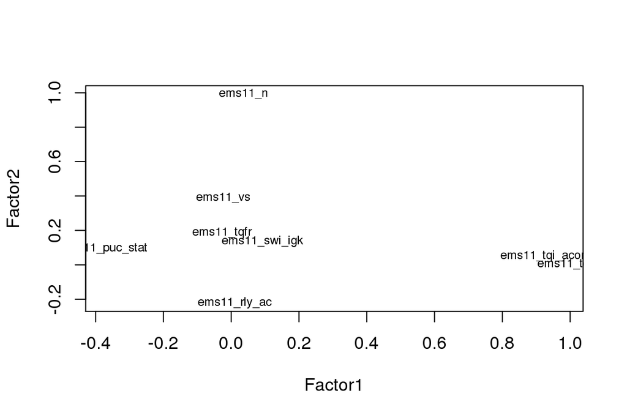

```r
load <- fit$loadings[,1:2]
plot(load,type="n") # set up plot
text(load,labels=names(test_df),cex=.7)
```

##### 회귀분석

```r
lm_df <- df_um_ems11[df_um_ems11$cnt<=30,c(1,4,6,8,9,10,11,12,16)]
g = lm(pct ~ ems11_swi_igk+ems11_puc_stat+ems11_rly_ac+ems11_tqi_acor+ems11_n+ems11_tqi+ems11_tqfr+ems11_vs, data = lm_df)
summary(g)
```

```
##
## Call:
## lm(formula = pct ~ ems11_swi_igk + ems11_puc_stat + ems11_rly_ac +
##     ems11_tqi_acor + ems11_n + ems11_tqi + ems11_tqfr + ems11_vs,
##     data = lm_df)
##
## Residuals:
##        Min         1Q     Median         3Q        Max
## -2.295e-07 -1.260e-07 -6.736e-08  6.535e-08  6.884e-07
##
## Coefficients:
##                  Estimate Std. Error t value Pr(>|t|)
## (Intercept)     2.240e-07  8.575e-08   2.613   0.0092 **
## ems11_swi_igk   5.721e-09  8.701e-08   0.066   0.9476
## ems11_puc_stat -8.243e-09  4.135e-08  -0.199   0.8420
## ems11_rly_ac   -3.186e-08  1.665e-08  -1.914   0.0561 .
## ems11_tqi_acor  2.743e-08  6.801e-09   4.033 6.17e-05 ***
## ems11_n        -6.909e-09  1.192e-08  -0.579   0.5625
## ems11_tqi      -2.981e-08  6.358e-09  -4.689 3.36e-06 ***
## ems11_tqfr     -2.032e-08  1.705e-08  -1.192   0.2337
## ems11_vs        3.603e-10  4.179e-09   0.086   0.9313
## ---
## Signif. codes:  0 '***' 0.001 '**' 0.01 '*' 0.05 '.' 0.1 ' ' 1
##
## Residual standard error: 1.901e-07 on 634 degrees of freedom
## Multiple R-squared:  0.03727,    Adjusted R-squared:  0.02513
## F-statistic: 3.068 on 8 and 634 DF,  p-value: 0.002124
```

```r
coefficients(g)
```

```
##    (Intercept)  ems11_swi_igk ems11_puc_stat   ems11_rly_ac ems11_tqi_acor
##   2.240293e-07   5.721003e-09  -8.242774e-09  -3.185622e-08   2.742919e-08
##        ems11_n      ems11_tqi     ems11_tqfr       ems11_vs
##  -6.908636e-09  -2.981135e-08  -2.032392e-08   3.603405e-10
```

```r
#anova(g)
# diagnostic plots
#graphics.off()
#layout(matrix(c(1,2,3,4),2,2)) # optional 4 graphs/page
#plot(g)
```

|  | vars | n | mean | sd | median | trimmed | mad | min | max | range | skew | kurtosis | se |
| --- | --- | --- | --- | --- | --- | --- | --- | --- | --- | --- | --- | --- | --- |
| ems12_can_vers | 1 | 3296.00 | 4.81 | 2.78 | 7.00 | 5.14 | 0.00 | 0.00 | 7.00 | 7.00 | -0.88 | -0.84 | 0.05 |
| ems12_conf_tcu | 2 | 3296.00 | 5.08 | 3.91 | 5.00 | 5.10 | 7.41 | 0.00 | 10.00 | 10.00 | 0.13 | -1.50 | 0.07 |
| ems12_obd_frf_ack | 3 | 3296.00 | 3.10 | 3.58 | 2.00 | 2.87 | 2.97 | 0.00 | 8.00 | 8.00 | 0.56 | -1.55 | 0.06 |
| ems12_tq_stnd | 4 | 3296.00 | 2.73 | 3.44 | 1.00 | 2.41 | 1.48 | 0.00 | 8.00 | 8.00 | 0.67 | -1.47 | 0.06 |
| ems12_mul_code | 5 | 3296.00 | 1.74 | 1.13 | 2.00 | 1.79 | 1.48 | 0.00 | 3.00 | 3.00 | -0.31 | -1.30 | 0.02 |
| ems12_temp_eng | 6 | 3296.00 | 2.31 | 1.38 | 2.00 | 2.36 | 1.48 | -2.00 | 5.00 | 7.00 | -0.13 | -1.05 | 0.02 |
| ems12_maf_fac_alti_mmv | 7 | 3296.00 | 4.47 | 0.50 | 4.00 | 4.46 | 0.00 | 0.00 | 5.00 | 5.00 | -0.07 | -0.17 | 0.01 |
| ems12_vb_off_act | 8 | 3296.00 | 0.00 | 0.00 | 0.00 | 0.00 | 0.00 | 0.00 | 0.00 | 0.00 |  |  | 0.00 |
| ems12_ack_es | 9 | 3296.00 | 0.09 | 0.28 | 0.00 | 0.00 | 0.00 | 0.00 | 1.00 | 1.00 | 2.89 | 6.34 | 0.00 |
| ems12_conf_mil_fmy | 10 | 3296.00 | 5.00 | 0.09 | 5.00 | 5.00 | 0.00 | 0.00 | 5.00 | 5.00 | -57.36 | 3289.00 | 0.00 |
| ems12_od_off_req | 11 | 3296.00 | 0.00 | 0.00 | 0.00 | 0.00 | 0.00 | 0.00 | 0.00 | 0.00 |  |  | 0.00 |
| ems12_acc_act | 12 | 3296.00 | 0.18 | 0.38 | 0.00 | 0.10 | 0.00 | 0.00 | 1.00 | 1.00 | 1.69 | 0.85 | 0.01 |
| ems12_clu_ack | 13 | 3296.00 | 0.22 | 0.42 | 0.00 | 0.15 | 0.00 | 0.00 | 1.00 | 1.00 | 1.33 | -0.24 | 0.01 |
| ems12_brake_act | 14 | 3296.00 | 1.20 | 0.40 | 1.00 | 1.12 | 0.00 | 0.00 | 2.00 | 2.00 | 1.50 | 0.30 | 0.01 |
| ems12_eng_chr | 15 | 3296.00 | 2.00 | 0.03 | 2.00 | 2.00 | 0.00 | 0.00 | 2.00 | 2.00 | -57.36 | 3289.00 | 0.00 |
| ems12_gp_ctl | 16 | 3296.00 | 0.33 | 0.47 | 0.00 | 0.28 | 0.00 | 0.00 | 1.00 | 1.00 | 0.74 | -1.46 | 0.01 |
| ems12_tps | 17 | 3296.00 | 1.65 | 2.77 | 1.00 | 1.23 | 2.97 | -3.00 | 9.00 | 12.00 | 1.07 | 0.10 | 0.05 |
| ems12_pv_av_can | 18 | 3296.00 | 2.68 | 2.68 | 2.00 | 2.34 | 2.97 | 0.00 | 9.00 | 9.00 | 0.77 | -0.46 | 0.05 |
| ems12_eng_vol | 19 | 3296.00 | 1.00 | 0.02 | 1.00 | 1.00 | 0.00 | 0.00 | 1.00 | 1.00 | -57.36 | 3289.00 | 0.00 |
| cnt | 20 | 3296.00 | 10804.62 | 38572.95 | 40.00 | 1712.53 | 57.82 | 1.00 | 525865.00 | 525864.00 | 6.69 | 60.18 | 671.88 |
| id | 21 | 3296.00 | 1648.50 | 951.62 | 1648.50 | 1648.50 | 1221.66 | 1.00 | 3296.00 | 3295.00 | 0.00 | -1.20 | 16.58 |
| pct | 22 | 3296.00 | 0.00 | 0.00 | 0.00 | 0.00 | 0.00 | 0.00 | 0.01 | 0.01 | 6.69 | 60.18 | 0.00 |

|  | vars | n | mean | sd | median | trimmed | mad | min | max | range | skew | kurtosis | se |
| --- | --- | --- | --- | --- | --- | --- | --- | --- | --- | --- | --- | --- | --- |
| ems14_im_autehn | 1 | 35.00 | 0.00 | 0.00 | 0.00 | 0.00 | 0.00 | 0.00 | 0.00 | 0.00 |  |  | 0.00 |
| ems14_l_mil | 2 | 35.00 | 0.40 | 0.50 | 0.00 | 0.38 | 0.00 | 0.00 | 1.00 | 1.00 | 0.39 | -1.90 | 0.08 |
| ems14_im_stat | 3 | 35.00 | 0.97 | 0.17 | 1.00 | 1.00 | 0.00 | 0.00 | 1.00 | 1.00 | -5.42 | 28.17 | 0.03 |
| ems14_amp_can | 4 | 35.00 | 7.43 | 1.75 | 8.00 | 7.69 | 1.48 | 0.00 | 9.00 | 9.00 | -2.17 | 6.65 | 0.30 |
| ems14_bat_alt_fr_duty | 5 | 35.00 | 0.00 | 0.00 | 0.00 | 0.00 | 0.00 | 0.00 | 0.00 | 0.00 |  |  | 0.00 |
| ems14_vb | 6 | 35.00 | 5.06 | 1.61 | 5.00 | 5.17 | 1.48 | 0.00 | 7.00 | 7.00 | -0.83 | 0.67 | 0.27 |
| cnt | 7 | 35.00 | 1017486.26 | 3676924.12 | 3875.00 | 93230.24 | 5728.77 | 1.00 | 20278159.00 | 20278158.00 | 4.27 | 18.80 | 621513.61 |
| id | 8 | 35.00 | 18.00 | 10.25 | 18.00 | 18.00 | 13.34 | 1.00 | 35.00 | 34.00 | 0.00 | -1.30 | 1.73 |
| pct | 9 | 35.00 | 0.03 | 0.10 | 0.00 | 0.00 | 0.00 | 0.00 | 0.57 | 0.57 | 4.27 | 18.80 | 0.02 |

|  | vars | n | mean | sd | median | trimmed | mad | min | max | range | skew | kurtosis | se |
| --- | --- | --- | --- | --- | --- | --- | --- | --- | --- | --- | --- | --- | --- |
| ems15_ecgpovrd | 1 | 7.00 | 0.43 | 0.53 | 0.00 | 0.43 | 0.00 | 0.00 | 1.00 | 1.00 | 0.23 | -2.20 | 0.20 |
| ems15_qecacc | 2 | 7.00 | 0.00 | 0.00 | 0.00 | 0.00 | 0.00 | 0.00 | 0.00 | 0.00 |  |  | 0.00 |
| ems15_ecfail | 3 | 7.00 | 0.00 | 0.00 | 0.00 | 0.00 | 0.00 | 0.00 | 0.00 | 0.00 |  |  | 0.00 |
| ems15_blecfail | 4 | 7.00 | 0.00 | 0.00 | 0.00 | 0.00 | 0.00 | 0.00 | 0.00 | 0.00 |  |  | 0.00 |
| ems15_fa_pv_can | 5 | 7.00 | 0.00 | 0.00 | 0.00 | 0.00 | 0.00 | 0.00 | 0.00 | 0.00 |  |  | 0.00 |
| ems15_intairtemp | 6 | 7.00 | 0.57 | 1.40 | 1.00 | 0.57 | 1.48 | -2.00 | 2.00 | 4.00 | -0.60 | -1.04 | 0.53 |
| ems15_state_dc_obd | 7 | 7.00 | 0.00 | 0.00 | 0.00 | 0.00 | 0.00 | 0.00 | 0.00 | 0.00 |  |  | 0.00 |
| ems15_inh_dc_obd | 8 | 7.00 | 0.00 | 0.00 | 0.00 | 0.00 | 0.00 | 0.00 | 0.00 | 0.00 |  |  | 0.00 |
| ems15_ctr_ig_cyc_obd | 9 | 7.00 | 0.00 | 0.00 | 0.00 | 0.00 | 0.00 | 0.00 | 0.00 | 0.00 |  |  | 0.00 |
| ems15_ctr_cdn_obd | 10 | 7.00 | 0.00 | 0.00 | 0.00 | 0.00 | 0.00 | 0.00 | 0.00 | 0.00 |  |  | 0.00 |
| cnt | 11 | 7.00 | 5087431.29 | 8089750.48 | 746094.00 | 5087431.29 | 1067818.93 | 2534.00 | 19926046.00 | 19923512.00 | 0.89 | -1.16 | 3057638.28 |
| id | 12 | 7.00 | 4.00 | 2.16 | 4.00 | 4.00 | 2.97 | 1.00 | 7.00 | 6.00 | 0.00 | -1.71 | 0.82 |
| pct | 13 | 7.00 | 0.14 | 0.23 | 0.02 | 0.14 | 0.03 | 0.00 | 0.56 | 0.56 | 0.89 | -1.16 | 0.09 |

|  | vars | n | mean | sd | median | trimmed | mad | min | max | range | skew | kurtosis | se |
| --- | --- | --- | --- | --- | --- | --- | --- | --- | --- | --- | --- | --- | --- |
| ems16_tqi_min | 1 | 1359.00 | 0.46 | 0.97 | 0.00 | 0.21 | 0.00 | 0.00 | 6.00 | 6.00 | 2.71 | 8.03 | 0.03 |
| ems16_tqi | 2 | 1359.00 | 3.17 | 2.01 | 3.00 | 3.07 | 1.48 | 0.00 | 9.00 | 9.00 | 0.44 | -0.25 | 0.05 |
| ems16_tqi_target | 3 | 1359.00 | 2.73 | 2.75 | 2.00 | 2.40 | 2.97 | 0.00 | 9.00 | 9.00 | 0.71 | -0.66 | 0.07 |
| ems16_glow_stat | 4 | 1359.00 | 0.03 | 0.18 | 0.00 | 0.00 | 0.00 | 0.00 | 1.00 | 1.00 | 5.09 | 23.91 | 0.00 |
| ems16_cruise_lamp_m | 5 | 1359.00 | 0.39 | 0.49 | 0.00 | 0.37 | 0.00 | 0.00 | 1.00 | 1.00 | 0.44 | -1.81 | 0.01 |
| ems16_cruise_lamp_s | 6 | 1359.00 | 0.17 | 0.37 | 0.00 | 0.09 | 0.00 | 0.00 | 1.00 | 1.00 | 1.77 | 1.13 | 0.01 |
| ems16_pre_fuel_cut_in | 7 | 1359.00 | 0.00 | 0.00 | 0.00 | 0.00 | 0.00 | 0.00 | 0.00 | 0.00 |  |  | 0.00 |
| ems16_eng_stat | 8 | 1359.00 | 2.65 | 0.83 | 3.00 | 2.86 | 0.00 | 0.00 | 3.00 | 3.00 | -2.11 | 2.94 | 0.02 |
| ems16_soak_time_error | 9 | 1359.00 | 0.00 | 0.00 | 0.00 | 0.00 | 0.00 | 0.00 | 0.00 | 0.00 |  |  | 0.00 |
| ems16_soak_time | 10 | 1359.00 | 0.49 | 1.93 | 0.00 | 0.00 | 0.00 | 0.00 | 10.00 | 10.00 | 4.15 | 16.26 | 0.05 |
| ems16_tqi_max | 11 | 1359.00 | 5.24 | 2.42 | 5.00 | 5.28 | 2.97 | 0.00 | 9.00 | 9.00 | -0.13 | -0.83 | 0.07 |
| ems16_spk_time_cur | 12 | 1359.00 | -3.00 | 0.00 | -3.00 | -3.00 | 0.00 | -3.00 | -3.00 | 0.00 |  |  | 0.00 |
| ems16_cf_ems_aclact | 13 | 1359.00 | 0.00 | 0.00 | 0.00 | 0.00 | 0.00 | 0.00 | 0.00 | 0.00 |  |  | 0.00 |
| cnt | 14 | 1359.00 | 26204.58 | 225485.24 | 24.00 | 380.63 | 34.10 | 1.00 | 3727912.00 | 3727911.00 | 12.62 | 176.06 | 6116.58 |
| id | 15 | 1359.00 | 680.00 | 392.45 | 680.00 | 680.00 | 504.08 | 1.00 | 1359.00 | 1358.00 | 0.00 | -1.20 | 10.65 |
| pct | 16 | 1359.00 | 0.00 | 0.01 | 0.00 | 0.00 | 0.00 | 0.00 | 0.10 | 0.10 | 12.62 | 176.06 | 0.00 |

|  | vars | n | mean | sd | median | trimmed | mad | min | max | range | skew | kurtosis | se |
| --- | --- | --- | --- | --- | --- | --- | --- | --- | --- | --- | --- | --- | --- |
| ems_h12_r_tqacnapvc | 1 | 1612.00 | 2.68 | 4.43 | 0.00 | 2.10 | 0.00 | 0.00 | 10.00 | 10.00 | 1.05 | -0.91 | 0.11 |
| ems_h12_r_pacnc | 2 | 1612.00 | 0.73 | 0.92 | 0.00 | 0.57 | 0.00 | 0.00 | 5.00 | 5.00 | 1.35 | 1.54 | 0.02 |
| ems_h12_tqi_b | 3 | 1612.00 | 2.89 | 2.42 | 2.00 | 2.64 | 2.97 | 0.00 | 9.00 | 9.00 | 0.72 | -0.35 | 0.06 |
| ems_h12_sld_vs | 4 | 1612.00 | 0.34 | 1.05 | 0.00 | 0.00 | 0.00 | 0.00 | 5.00 | 5.00 | 3.00 | 7.67 | 0.03 |
| ems_h12_cf_cdastat | 5 | 1612.00 | 0.00 | 0.00 | 0.00 | 0.00 | 0.00 | 0.00 | 0.00 | 0.00 |  |  | 0.00 |
| ems_h12_cf_ems_isgstat | 6 | 1612.00 | 1.19 | 1.58 | 0.00 | 0.97 | 0.00 | 0.00 | 7.00 | 7.00 | 0.92 | -0.46 | 0.04 |
| ems_h12_cf_ems_oilchg | 7 | 1612.00 | 0.00 | 0.00 | 0.00 | 0.00 | 0.00 | 0.00 | 0.00 | 0.00 |  |  | 0.00 |
| ems_h12_cf_ems_etclimpmod | 8 | 1612.00 | 0.00 | 0.00 | 0.00 | 0.00 | 0.00 | 0.00 | 0.00 | 0.00 |  |  | 0.00 |
| ems_h12_r_nengidltgc | 9 | 1612.00 | 3.10 | 0.34 | 3.00 | 3.00 | 0.00 | 0.00 | 5.00 | 5.00 | 2.59 | 13.53 | 0.01 |
| ems_h12_cf_ems_uptargr | 10 | 1612.00 | 0.12 | 0.33 | 0.00 | 0.03 | 0.00 | 0.00 | 1.00 | 1.00 | 2.32 | 3.40 | 0.01 |
| ems_h12_cf_ems_downtargr | 11 | 1612.00 | 0.08 | 0.28 | 0.00 | 0.00 | 0.00 | 0.00 | 1.00 | 1.00 | 2.99 | 6.93 | 0.01 |
| ems_h12_cf_ems_descurgr | 12 | 1612.00 | 1.46 | 2.05 | 0.00 | 1.12 | 0.00 | 0.00 | 6.00 | 6.00 | 1.03 | -0.48 | 0.05 |
| ems_h12_cf_ems_sldact | 13 | 1612.00 | 0.00 | 0.00 | 0.00 | 0.00 | 0.00 | 0.00 | 0.00 | 0.00 |  |  | 0.00 |
| ems_h12_cf_ems_sldposact | 14 | 1612.00 | 0.00 | 0.00 | 0.00 | 0.00 | 0.00 | 0.00 | 0.00 | 0.00 |  |  | 0.00 |
| ems_h12_cf_ems_hpresstat | 15 | 1612.00 | 0.00 | 0.00 | 0.00 | 0.00 | 0.00 | 0.00 | 0.00 | 0.00 |  |  | 0.00 |
| ems_h12_cf_ems_isgbuz | 16 | 1612.00 | 0.04 | 0.20 | 0.00 | 0.00 | 0.00 | 0.00 | 1.00 | 1.00 | 4.71 | 20.20 | 0.00 |
| ems_h12_cf_ems_idlstpfco | 17 | 1612.00 | 0.00 | 0.00 | 0.00 | 0.00 | 0.00 | 0.00 | 0.00 | 0.00 |  |  | 0.00 |
| ems_h12_cf_ems_fcopen | 18 | 1612.00 | 0.00 | 0.00 | 0.00 | 0.00 | 0.00 | 0.00 | 0.00 | 0.00 |  |  | 0.00 |
| ems_h12_cf_ems_actecoact | 19 | 1612.00 | 0.30 | 0.46 | 0.00 | 0.25 | 0.00 | 0.00 | 1.00 | 1.00 | 0.86 | -1.26 | 0.01 |
| ems_h12_cf_ems_engrunnorm | 20 | 1612.00 | 0.82 | 0.38 | 1.00 | 0.90 | 0.00 | 0.00 | 1.00 | 1.00 | -1.66 | 0.76 | 0.01 |
| ems_h12_cf_ems_isgstat2 | 21 | 1612.00 | 0.10 | 0.54 | 0.00 | 0.00 | 0.00 | 0.00 | 3.00 | 3.00 | 5.18 | 24.85 | 0.01 |
| cnt | 22 | 1612.00 | 22091.82 | 183356.00 | 22.00 | 236.04 | 31.13 | 1.00 | 4007872.00 | 4007871.00 | 13.79 | 228.17 | 4566.81 |
| id | 23 | 1612.00 | 806.50 | 465.49 | 806.50 | 806.50 | 597.49 | 1.00 | 1612.00 | 1611.00 | 0.00 | -1.20 | 11.59 |
| pct | 24 | 1612.00 | 0.00 | 0.01 | 0.00 | 0.00 | 0.00 | 0.00 | 0.11 | 0.11 | 13.79 | 228.17 | 0.00 |

|  | vars | n | mean | sd | median | trimmed | mad | min | max | range | skew | kurtosis | se |
| --- | --- | --- | --- | --- | --- | --- | --- | --- | --- | --- | --- | --- | --- |
| tcu11_tqi_tcu_inc | 1 | 674.00 | 0.02 | 0.14 | 0.00 | 0.00 | 0.00 | 0.00 | 2.00 | 2.00 | 9.24 | 94.76 | 0.01 |
| tcu11_g_sel_disp | 2 | 674.00 | 6.00 | 2.40 | 5.00 | 5.80 | 0.00 | 0.00 | 15.00 | 15.00 | 1.18 | 4.51 | 0.09 |
| tcu11_f_tcu | 3 | 674.00 | 0.13 | 0.34 | 0.00 | 0.04 | 0.00 | 0.00 | 2.00 | 2.00 | 2.28 | 3.61 | 0.01 |
| tcu11_tcu_type | 4 | 674.00 | 1.00 | 0.04 | 1.00 | 1.00 | 0.00 | 0.00 | 1.00 | 1.00 | -25.85 | 667.01 | 0.00 |
| tcu11_tcu_obd | 5 | 674.00 | 0.26 | 0.67 | 0.00 | 0.07 | 0.00 | 0.00 | 2.00 | 2.00 | 2.21 | 2.88 | 0.03 |
| tcu11_swi_gs | 6 | 674.00 | 0.75 | 0.43 | 1.00 | 0.81 | 0.00 | 0.00 | 1.00 | 1.00 | -1.17 | -0.64 | 0.02 |
| tcu11_gear_type | 7 | 674.00 | 5.99 | 0.23 | 6.00 | 6.00 | 0.00 | 0.00 | 6.00 | 6.00 | -25.85 | 667.01 | 0.01 |
| tcu11_tqi_tcu | 8 | 674.00 | 5.99 | 3.09 | 7.00 | 6.26 | 2.97 | 0.00 | 9.00 | 9.00 | -0.40 | -1.42 | 0.12 |
| tcu11_temp_at | 9 | 674.00 | 1.39 | 1.06 | 1.00 | 1.35 | 1.48 | -1.00 | 4.00 | 5.00 | 0.25 | -0.80 | 0.04 |
| tcu11_n_tc | 10 | 674.00 | 0.66 | 0.72 | 1.00 | 0.57 | 1.48 | 0.00 | 3.00 | 3.00 | 0.67 | -0.67 | 0.03 |
| tcu11_swi_cc | 11 | 674.00 | 0.84 | 0.84 | 1.00 | 0.80 | 1.48 | 0.00 | 2.00 | 2.00 | 0.30 | -1.50 | 0.03 |
| cnt | 12 | 674.00 | 52836.82 | 345260.72 | 24.00 | 583.01 | 34.10 | 1.00 | 4645304.00 | 4645303.00 | 8.67 | 84.39 | 13298.95 |
| id | 13 | 674.00 | 337.50 | 194.71 | 337.50 | 337.50 | 249.82 | 1.00 | 674.00 | 673.00 | 0.00 | -1.21 | 7.50 |
| pct | 14 | 674.00 | 0.00 | 0.01 | 0.00 | 0.00 | 0.00 | 0.00 | 0.13 | 0.13 | 8.67 | 84.39 | 0.00 |

|  | vars | n | mean | sd | median | trimmed | mad | min | max | range | skew | kurtosis | se |
| --- | --- | --- | --- | --- | --- | --- | --- | --- | --- | --- | --- | --- | --- |
| tcu12_etl_tcu | 1 | 9979.00 | 6.58 | 3.21 | 6.00 | 6.77 | 5.93 | 0.00 | 10.00 | 10.00 | -0.18 | -1.56 | 0.03 |
| tcu12_cur_gr | 2 | 9979.00 | 3.58 | 1.93 | 4.00 | 3.56 | 1.48 | 0.00 | 14.00 | 14.00 | 1.20 | 6.30 | 0.02 |
| tcu12_cf_tcu_alive | 3 | 9979.00 | 1.50 | 1.12 | 1.00 | 1.50 | 1.48 | 0.00 | 3.00 | 3.00 | 0.00 | -1.36 | 0.01 |
| tcu12_cf_tcu_chksum | 4 | 9979.00 | 1.50 | 1.12 | 2.00 | 1.51 | 1.48 | 0.00 | 3.00 | 3.00 | -0.01 | -1.36 | 0.01 |
| tcu12_vs_tcu | 5 | 9979.00 | 1.76 | 1.52 | 2.00 | 1.57 | 1.48 | 0.00 | 8.00 | 8.00 | 1.00 | 0.96 | 0.02 |
| tcu12_fuel_cut_tcu | 6 | 9979.00 | 0.00 | 0.00 | 0.00 | 0.00 | 0.00 | 0.00 | 0.00 | 0.00 |  |  | 0.00 |
| tcu12_inh_fuel_cut | 7 | 9979.00 | 0.52 | 0.50 | 1.00 | 0.53 | 0.00 | 0.00 | 1.00 | 1.00 | -0.08 | -1.99 | 0.01 |
| tcu12_idle_up_tcu | 8 | 9979.00 | 0.00 | 0.00 | 0.00 | 0.00 | 0.00 | 0.00 | 0.00 | 0.00 |  |  | 0.00 |
| tcu12_n_inc_tcu | 9 | 9979.00 | 0.00 | 0.00 | 0.00 | 0.00 | 0.00 | 0.00 | 0.00 | 0.00 |  |  | 0.00 |
| tcu12_spk_rtd_tcu | 10 | 9979.00 | 5.00 | 0.10 | 5.00 | 5.00 | 0.00 | -5.00 | 5.00 | 10.00 | -99.86 | 9972.00 | 0.00 |
| tcu12_n_tc_raw | 11 | 9979.00 | 0.58 | 0.62 | 1.00 | 0.51 | 1.48 | 0.00 | 3.00 | 3.00 | 0.60 | -0.56 | 0.01 |
| tcu12_vs_tcu_decimal | 12 | 9979.00 | 4.48 | 2.89 | 4.00 | 4.48 | 4.45 | 0.00 | 9.00 | 9.00 | -0.00 | -1.24 | 0.03 |
| cnt | 13 | 9979.00 | 3568.70 | 50074.40 | 9.00 | 55.60 | 11.86 | 1.00 | 2338610.00 | 2338609.00 | 41.70 | 1886.01 | 501.27 |
| id | 14 | 9979.00 | 4990.00 | 2880.83 | 4990.00 | 4990.00 | 3699.09 | 1.00 | 9979.00 | 9978.00 | 0.00 | -1.20 | 28.84 |
| pct | 15 | 9979.00 | 0.00 | 0.00 | 0.00 | 0.00 | 0.00 | 0.00 | 0.07 | 0.07 | 41.70 | 1886.01 | 0.00 |

|  | vars | n | mean | sd | median | trimmed | mad | min | max | range | skew | kurtosis | se |
| --- | --- | --- | --- | --- | --- | --- | --- | --- | --- | --- | --- | --- | --- |
| tcu13_n_tgt_lup | 1 | 546.00 | 10.00 | 0.00 | 10.00 | 10.00 | 0.00 | 10.00 | 10.00 | 0.00 |  |  | 0.00 |
| tcu13_slope_tcu | 2 | 546.00 | 0.51 | 1.86 | 0.00 | 0.45 | 1.48 | -4.00 | 5.00 | 9.00 | 0.26 | 0.04 | 0.08 |
| tcu13_cf_tcu_inhcda | 3 | 546.00 | 0.00 | 0.00 | 0.00 | 0.00 | 0.00 | 0.00 | 0.00 | 0.00 |  |  | 0.00 |
| tcu13_cf_tcu_isginhib | 4 | 546.00 | 0.29 | 0.46 | 0.00 | 0.24 | 0.00 | 0.00 | 1.00 | 1.00 | 0.91 | -1.18 | 0.02 |
| tcu13_cf_tcu_bkeonreq | 5 | 546.00 | 0.16 | 0.37 | 0.00 | 0.08 | 0.00 | 0.00 | 1.00 | 1.00 | 1.80 | 1.25 | 0.02 |
| tcu13_cf_tcu_ncstat | 6 | 546.00 | 0.36 | 0.81 | 0.00 | 0.13 | 0.00 | 0.00 | 3.00 | 3.00 | 2.28 | 4.09 | 0.03 |
| tcu13_cf_tcu_targr | 7 | 546.00 | 2.55 | 2.94 | 1.00 | 2.10 | 1.48 | 0.00 | 14.00 | 14.00 | 2.04 | 5.37 | 0.13 |
| tcu13_cf_tcu_shfpatt | 8 | 546.00 | 3.78 | 3.61 | 2.00 | 3.60 | 2.97 | 0.00 | 9.00 | 9.00 | 0.37 | -1.54 | 0.15 |
| tcu13_cf_tcu_inhvis | 9 | 546.00 | 0.00 | 0.00 | 0.00 | 0.00 | 0.00 | 0.00 | 0.00 | 0.00 |  |  | 0.00 |
| tcu13_cf_tcu_prelreq | 10 | 546.00 | 0.00 | 0.00 | 0.00 | 0.00 | 0.00 | 0.00 | 0.00 | 0.00 |  |  | 0.00 |
| tcu13_cf_tcu_itphase | 11 | 546.00 | 0.00 | 0.00 | 0.00 | 0.00 | 0.00 | 0.00 | 0.00 | 0.00 |  |  | 0.00 |
| tcu13_cf_tcu_actecordy | 12 | 546.00 | 0.00 | 0.00 | 0.00 | 0.00 | 0.00 | 0.00 | 0.00 | 0.00 |  |  | 0.00 |
| tcu13_cf_tcu_tqgrdlim | 13 | 546.00 | 10.00 | 0.00 | 10.00 | 10.00 | 0.00 | 10.00 | 10.00 | 0.00 |  |  | 0.00 |
| tcu13_cr_tcu_isgtgtrpm | 14 | 546.00 | 0.42 | 1.28 | 0.00 | 0.01 | 0.00 | 0.00 | 6.00 | 6.00 | 2.76 | 5.99 | 0.05 |
| tcu13_cf_tcu_sptrdy | 15 | 546.00 | 0.62 | 0.49 | 1.00 | 0.65 | 0.00 | 0.00 | 1.00 | 1.00 | -0.49 | -1.76 | 0.02 |
| tcu13_cf_tcu_sbwpinfo | 16 | 546.00 | 0.00 | 0.00 | 0.00 | 0.00 | 0.00 | 0.00 | 0.00 | 0.00 |  |  | 0.00 |
| cnt | 17 | 547.00 | 65104.24 | 377250.07 | 88.00 | 3800.08 | 128.99 | 1.00 | 7054374.00 | 7054373.00 | 12.85 | 217.03 | 16130.05 |
| id | 18 | 547.00 | 274.00 | 158.05 | 274.00 | 274.00 | 203.12 | 1.00 | 547.00 | 546.00 | 0.00 | -1.21 | 6.76 |
| pct | 19 | 547.00 | 0.00 | 0.01 | 0.00 | 0.00 | 0.00 | 0.00 | 0.20 | 0.20 | 12.85 | 217.03 | 0.00 |

|  | vars | n | mean | sd | median | trimmed | mad | min | max | range | skew | kurtosis | se |
| --- | --- | --- | --- | --- | --- | --- | --- | --- | --- | --- | --- | --- | --- |
| fatc11_cr_fatc_tqacnout | 1 | 2361.00 | 1.64 | 1.61 | 1.00 | 1.45 | 1.48 | 0.00 | 6.00 | 6.00 | 0.64 | -0.76 | 0.03 |
| fatc11_cf_fatc_acnrqswi | 2 | 2361.00 | 0.56 | 0.50 | 1.00 | 0.57 | 0.00 | 0.00 | 1.00 | 1.00 | -0.24 | -1.94 | 0.01 |
| fatc11_cf_fatc_acncltenrq | 3 | 2361.00 | 0.53 | 0.50 | 1.00 | 0.54 | 0.00 | 0.00 | 1.00 | 1.00 | -0.12 | -1.99 | 0.01 |
| fatc11_cf_fatc_ecvflt | 4 | 2361.00 | 0.00 | 0.00 | 0.00 | 0.00 | 0.00 | 0.00 | 0.00 | 0.00 |  |  | 0.00 |
| fatc11_cf_fatc_blwron | 5 | 2361.00 | 0.84 | 0.36 | 1.00 | 0.93 | 0.00 | 0.00 | 1.00 | 1.00 | -1.88 | 1.55 | 0.01 |
| fatc11_cf_fatc_iden | 6 | 2361.00 | 1.00 | 0.00 | 1.00 | 1.00 | 0.00 | 1.00 | 1.00 | 0.00 |  |  | 0.00 |
| fatc11_cf_fatc_blwrmax | 7 | 2361.00 | 0.19 | 0.39 | 0.00 | 0.12 | 0.00 | 0.00 | 1.00 | 1.00 | 1.55 | 0.41 | 0.01 |
| fatc11_cf_fatc_engstartreq | 8 | 2361.00 | 0.03 | 0.17 | 0.00 | 0.00 | 0.00 | 0.00 | 1.00 | 1.00 | 5.46 | 27.80 | 0.00 |
| fatc11_cf_fatc_isgstopreq | 9 | 2361.00 | 0.45 | 0.50 | 0.00 | 0.44 | 0.00 | 0.00 | 1.00 | 1.00 | 0.21 | -1.96 | 0.01 |
| fatc11_cf_fatc_ctrinf | 10 | 2361.00 | 2.00 | 0.00 | 2.00 | 2.00 | 0.00 | 2.00 | 2.00 | 0.00 |  |  | 0.00 |
| fatc11_cf_fatc_msgcnt | 11 | 2361.00 | 7.43 | 4.62 | 7.00 | 7.42 | 5.93 | 0.00 | 15.00 | 15.00 | 0.02 | -1.21 | 0.10 |
| fatc11_cr_fatc_outtemp | 12 | 2361.00 | 0.56 | 0.84 | 0.00 | 0.53 | 1.48 | -2.00 | 2.00 | 4.00 | 0.22 | -0.35 | 0.02 |
| fatc11_cr_fatc_outtempsns | 13 | 2361.00 | 0.83 | 0.96 | 1.00 | 0.87 | 1.48 | -2.00 | 3.00 | 5.00 | -0.25 | -0.06 | 0.02 |
| fatc11_cf_fatc_compload | 14 | 2361.00 | 0.00 | 0.00 | 0.00 | 0.00 | 0.00 | 0.00 | 0.00 | 0.00 |  |  | 0.00 |
| fatc11_cf_fatc_activeeco | 15 | 2361.00 | 0.00 | 0.00 | 0.00 | 0.00 | 0.00 | 0.00 | 0.00 | 0.00 |  |  | 0.00 |
| fatc11_cf_fatc_autoactivation | 16 | 2361.00 | 0.00 | 0.00 | 0.00 | 0.00 | 0.00 | 0.00 | 0.00 | 0.00 |  |  | 0.00 |
| fatc11_cf_fatc_defsw | 17 | 2361.00 | 0.00 | 0.00 | 0.00 | 0.00 | 0.00 | 0.00 | 0.00 | 0.00 |  |  | 0.00 |
| fatc11_cf_fatc_ptcrlystat | 18 | 2361.00 | 0.00 | 0.00 | 0.00 | 0.00 | 0.00 | 0.00 | 0.00 | 0.00 |  |  | 0.00 |
| cnt | 19 | 2362.00 | 15077.06 | 94571.19 | 33.00 | 396.86 | 47.44 | 1.00 | 969195.00 | 969194.00 | 8.31 | 73.50 | 1945.89 |
| id | 20 | 2362.00 | 1181.50 | 681.99 | 1181.50 | 1181.50 | 875.48 | 1.00 | 2362.00 | 2361.00 | 0.00 | -1.20 | 14.03 |
| pct | 21 | 2362.00 | 0.00 | 0.00 | 0.00 | 0.00 | 0.00 | 0.00 | 0.03 | 0.03 | 8.31 | 73.50 | 0.00 |

|  | vars | n | mean | sd | median | trimmed | mad | min | max | range | skew | kurtosis | se |
| --- | --- | --- | --- | --- | --- | --- | --- | --- | --- | --- | --- | --- | --- |
| bat11_bat_snsr_i | 1 | 4805.00 | -0.08 | 3.78 | 0.00 | -0.10 | 5.93 | -5.00 | 5.00 | 10.00 | 0.02 | -1.63 | 0.05 |
| bat11_bat_soc | 2 | 4805.00 | 6.67 | 2.05 | 7.00 | 6.81 | 1.48 | 0.00 | 10.00 | 10.00 | -0.69 | 0.52 | 0.03 |
| bat11_bat_snsr_v | 3 | 4805.00 | 12.51 | 1.20 | 13.00 | 12.57 | 1.48 | 6.00 | 14.00 | 8.00 | -0.33 | -0.79 | 0.02 |
| bat11_bat_snsr_temp | 4 | 4805.00 | 0.41 | 0.58 | 0.00 | 0.33 | 0.00 | -2.00 | 2.00 | 4.00 | 1.04 | 0.16 | 0.01 |
| bat11_bat_snsr_state | 5 | 4805.00 | 0.41 | 0.49 | 0.00 | 0.39 | 0.00 | 0.00 | 1.00 | 1.00 | 0.37 | -1.86 | 0.01 |
| bat11_bat_soh | 6 | 4805.00 | 9.01 | 1.16 | 9.00 | 9.20 | 1.48 | 0.00 | 10.00 | 10.00 | -1.24 | 1.54 | 0.02 |
| bat11_bat_snsr_invalid | 7 | 4805.00 | 0.00 | 0.00 | 0.00 | 0.00 | 0.00 | 0.00 | 0.00 | 0.00 |  |  | 0.00 |
| bat11_bat_sof | 8 | 4805.00 | 7.40 | 1.23 | 7.00 | 7.40 | 1.48 | 0.00 | 12.00 | 12.00 | -0.35 | 5.06 | 0.02 |
| bat11_bat_snsr_error | 9 | 4805.00 | 0.00 | 0.01 | 0.00 | 0.00 | 0.00 | 0.00 | 1.00 | 1.00 | 69.27 | 4798.00 | 0.00 |
| cnt | 10 | 4806.00 | 7409.91 | 56865.39 | 31.00 | 287.56 | 44.48 | 1.00 | 1896894.00 | 1896893.00 | 17.08 | 401.89 | 820.27 |
| id | 11 | 4806.00 | 2403.50 | 1387.52 | 2403.50 | 2403.50 | 1781.34 | 1.00 | 4806.00 | 4805.00 | 0.00 | -1.20 | 20.01 |
| pct | 12 | 4806.00 | 0.00 | 0.00 | 0.00 | 0.00 | 0.00 | 0.00 | 0.05 | 0.05 | 17.08 | 401.89 | 0.00 |

|  | vars | n | mean | sd | median | trimmed | mad | min | max | range | skew | kurtosis | se |
| --- | --- | --- | --- | --- | --- | --- | --- | --- | --- | --- | --- | --- | --- |
| cgw1_cf_gway_ignsw | 1 | 12191.00 | 2.62 | 1.06 | 3.00 | 2.85 | 0.00 | 0.00 | 4.00 | 4.00 | -1.89 | 2.15 | 0.01 |
| cgw1_cf_gway_rkecmd | 2 | 12191.00 | 0.05 | 0.40 | 0.00 | 0.00 | 0.00 | 0.00 | 5.00 | 5.00 | 8.96 | 86.50 | 0.00 |
| cgw1_cf_gway_drvkeylocksw | 3 | 12191.00 | 0.00 | 0.03 | 0.00 | 0.00 | 0.00 | 0.00 | 1.00 | 1.00 | 38.99 | 1518.63 | 0.00 |
| cgw1_cf_gway_drvkeyunlocksw | 4 | 12191.00 | 0.00 | 0.03 | 0.00 | 0.00 | 0.00 | 0.00 | 1.00 | 1.00 | 36.76 | 1349.33 | 0.00 |
| cgw1_cf_gway_drvdrsw | 5 | 12191.00 | 0.26 | 0.44 | 0.00 | 0.20 | 0.00 | 0.00 | 1.00 | 1.00 | 1.09 | -0.81 | 0.00 |
| cgw1_cf_gway_drvseatbeltsw | 6 | 12191.00 | 0.41 | 0.49 | 0.00 | 0.38 | 0.00 | 0.00 | 1.00 | 1.00 | 0.38 | -1.85 | 0.00 |
| cgw1_cf_gway_trunktgsw | 7 | 12191.00 | 0.17 | 0.37 | 0.00 | 0.09 | 0.00 | 0.00 | 1.00 | 1.00 | 1.77 | 1.15 | 0.00 |
| cgw1_cf_gway_astseatbeltsw | 8 | 12191.00 | 1.00 | 0.00 | 1.00 | 1.00 | 0.00 | 1.00 | 1.00 | 0.00 |  |  | 0.00 |
| cgw1_cf_gway_smkoption | 9 | 12191.00 | 1.00 | 0.00 | 1.00 | 1.00 | 0.00 | 1.00 | 1.00 | 0.00 |  |  | 0.00 |
| cgw1_cf_gway_hoodsw | 10 | 12191.00 | 0.01 | 0.11 | 0.00 | 0.00 | 0.00 | 0.00 | 1.00 | 1.00 | 8.97 | 78.50 | 0.00 |
| cgw1_cf_gway_turnsiglh | 11 | 12191.00 | 0.33 | 0.47 | 0.00 | 0.29 | 0.00 | 0.00 | 1.00 | 1.00 | 0.73 | -1.47 | 0.00 |
| cgw1_cf_gway_wiperintt | 12 | 12191.00 | 1.97 | 1.46 | 2.00 | 1.96 | 1.48 | 0.00 | 4.00 | 4.00 | 0.02 | -1.33 | 0.01 |
| cgw1_cf_gway_wiperintsw | 13 | 12191.00 | 0.00 | 0.00 | 0.00 | 0.00 | 0.00 | 0.00 | 0.00 | 0.00 |  |  | 0.00 |
| cgw1_cf_gway_wiperlowsw | 14 | 12191.00 | 0.03 | 0.18 | 0.00 | 0.00 | 0.00 | 0.00 | 1.00 | 1.00 | 5.08 | 23.78 | 0.00 |
| cgw1_cf_gway_wiperhighsw | 15 | 12191.00 | 0.01 | 0.09 | 0.00 | 0.00 | 0.00 | 0.00 | 1.00 | 1.00 | 11.25 | 124.68 | 0.00 |
| cgw1_cf_gway_wiperautosw | 16 | 12191.00 | 0.35 | 0.48 | 0.00 | 0.31 | 0.00 | 0.00 | 1.00 | 1.00 | 0.64 | -1.60 | 0.00 |
| cgw1_cf_gway_rainsnsstate | 17 | 12191.00 | 0.00 | 0.00 | 0.00 | 0.00 | 0.00 | 0.00 | 0.00 | 0.00 |  |  | 0.00 |
| cgw1_cf_gway_headlamplow | 18 | 12191.00 | 0.46 | 0.50 | 0.00 | 0.44 | 0.00 | 0.00 | 1.00 | 1.00 | 0.18 | -1.97 | 0.00 |
| cgw1_cf_gway_headlamphigh | 19 | 12191.00 | 0.03 | 0.18 | 0.00 | 0.00 | 0.00 | 0.00 | 1.00 | 1.00 | 5.32 | 26.29 | 0.00 |
| cgw1_cf_gway_hazardsw | 20 | 12191.00 | 0.27 | 0.44 | 0.00 | 0.21 | 0.00 | 0.00 | 1.00 | 1.00 | 1.03 | -0.93 | 0.00 |
| cgw1_cf_gway_astdrsw | 21 | 12191.00 | 0.23 | 0.42 | 0.00 | 0.16 | 0.00 | 0.00 | 1.00 | 1.00 | 1.29 | -0.32 | 0.00 |
| cgw1_cf_gway_defoggerrly | 22 | 12191.00 | 0.16 | 0.37 | 0.00 | 0.07 | 0.00 | 0.00 | 1.00 | 1.00 | 1.87 | 1.50 | 0.00 |
| cgw1_cf_gway_alightstat | 23 | 12191.00 | 0.59 | 0.49 | 1.00 | 0.61 | 0.00 | 0.00 | 1.00 | 1.00 | -0.35 | -1.88 | 0.00 |
| cgw1_cf_gway_lightswstate | 24 | 12191.00 | 0.00 | 0.00 | 0.00 | 0.00 | 0.00 | 0.00 | 0.00 | 0.00 |  |  | 0.00 |
| cgw1_cf_gway_frt_fog_act | 25 | 12191.00 | 0.33 | 0.47 | 0.00 | 0.28 | 0.00 | 0.00 | 1.00 | 1.00 | 0.75 | -1.44 | 0.00 |
| cgw1_cf_gway_tsiglhsw | 26 | 12191.00 | 0.00 | 0.00 | 0.00 | 0.00 | 0.00 | 0.00 | 0.00 | 0.00 |  |  | 0.00 |
| cgw1_cf_gway_tsigrhsw | 27 | 12191.00 | 0.00 | 0.00 | 0.00 | 0.00 | 0.00 | 0.00 | 0.00 | 0.00 |  |  | 0.00 |
| cgw1_cf_gway_drivetypeoption | 28 | 12191.00 | 0.00 | 0.00 | 0.00 | 0.00 | 0.00 | 0.00 | 0.00 | 0.00 |  |  | 0.00 |
| cgw1_cf_gway_starterrlystate | 29 | 12191.00 | 0.03 | 0.17 | 0.00 | 0.00 | 0.00 | 0.00 | 1.00 | 1.00 | 5.54 | 28.70 | 0.00 |
| cgw1_cf_gway_passiveaccesslock | 30 | 12191.00 | 0.00 | 0.06 | 0.00 | 0.00 | 0.00 | 0.00 | 1.00 | 1.00 | 17.59 | 307.54 | 0.00 |
| cgw1_cf_gway_passiveaccessunlock | 31 | 12191.00 | 0.02 | 0.16 | 0.00 | 0.00 | 0.00 | 0.00 | 3.00 | 3.00 | 9.73 | 125.19 | 0.00 |
| cgw1_cf_gway_passingsw | 32 | 12191.00 | 0.00 | 0.00 | 0.00 | 0.00 | 0.00 | 0.00 | 0.00 | 0.00 |  |  | 0.00 |
| cgw1_cf_gway_hlphighsw | 33 | 12191.00 | 0.00 | 0.00 | 0.00 | 0.00 | 0.00 | 0.00 | 0.00 | 0.00 |  |  | 0.00 |
| cgw1_cf_gway_inhibitrmt | 34 | 12191.00 | 0.15 | 0.36 | 0.00 | 0.06 | 0.00 | 0.00 | 1.00 | 1.00 | 1.98 | 1.92 | 0.00 |
| cgw1_c_sunroofopenstate | 35 | 12191.00 | 0.12 | 0.32 | 0.00 | 0.02 | 0.00 | 0.00 | 1.00 | 1.00 | 2.35 | 3.54 | 0.00 |
| cgw1_cf_gway_parkbrakesw | 36 | 12191.00 | 0.33 | 0.47 | 0.00 | 0.29 | 0.00 | 0.00 | 1.00 | 1.00 | 0.71 | -1.49 | 0.00 |
| cgw1_cf_gway_turnsigrh | 37 | 12191.00 | 0.34 | 0.47 | 0.00 | 0.29 | 0.00 | 0.00 | 1.00 | 1.00 | 0.70 | -1.52 | 0.00 |
| cnt | 38 | 12192.00 | 2920.93 | 29777.83 | 20.00 | 115.74 | 28.17 | 1.00 | 1151285.00 | 1151284.00 | 22.95 | 643.30 | 269.68 |
| id | 39 | 12192.00 | 6096.50 | 3519.67 | 6096.50 | 6096.50 | 4518.96 | 1.00 | 12192.00 | 12191.00 | 0.00 | -1.20 | 31.88 |
| pct | 40 | 12192.00 | 0.00 | 0.00 | 0.00 | 0.00 | 0.00 | 0.00 | 0.03 | 0.03 | 22.95 | 643.30 | 0.00 |

|  | vars | n | mean | sd | median | trimmed | mad | min | max | range | skew | kurtosis | se |
| --- | --- | --- | --- | --- | --- | --- | --- | --- | --- | --- | --- | --- | --- |
| esp12_lat_accel | 1 | 72.00 | -0.31 | 1.77 | 0.00 | -0.22 | 1.48 | -5.00 | 4.00 | 9.00 | -0.56 | 1.18 | 0.21 |
| esp12_lat_accel_stat | 2 | 72.00 | 0.14 | 0.35 | 0.00 | 0.05 | 0.00 | 0.00 | 1.00 | 1.00 | 2.05 | 2.21 | 0.04 |
| esp12_lat_accel_diag | 3 | 72.00 | 0.00 | 0.00 | 0.00 | 0.00 | 0.00 | 0.00 | 0.00 | 0.00 |  |  | 0.00 |
| esp12_long_accel | 4 | 72.00 | -0.82 | 1.73 | -0.50 | -0.78 | 2.22 | -5.00 | 3.00 | 8.00 | -0.26 | -0.49 | 0.20 |
| esp12_long_accel_stat | 5 | 72.00 | 0.14 | 0.35 | 0.00 | 0.05 | 0.00 | 0.00 | 1.00 | 1.00 | 2.05 | 2.21 | 0.04 |
| esp12_long_accel_diag | 6 | 72.00 | 0.00 | 0.00 | 0.00 | 0.00 | 0.00 | 0.00 | 0.00 | 0.00 |  |  | 0.00 |
| esp12_cyl_pres | 7 | 72.00 | 0.75 | 0.98 | 0.00 | 0.59 | 0.00 | 0.00 | 4.00 | 4.00 | 1.22 | 0.81 | 0.11 |
| esp12_cyl_pres_stat | 8 | 72.00 | 0.14 | 0.35 | 0.00 | 0.05 | 0.00 | 0.00 | 1.00 | 1.00 | 2.05 | 2.21 | 0.04 |
| esp12_cyl_press_diag | 9 | 72.00 | 0.00 | 0.00 | 0.00 | 0.00 | 0.00 | 0.00 | 0.00 | 0.00 |  |  | 0.00 |
| esp12_yaw_rate | 10 | 72.00 | 0.00 | 0.00 | 0.00 | 0.00 | 0.00 | 0.00 | 0.00 | 0.00 |  |  | 0.00 |
| esp12_yaw_rate_stat | 11 | 72.00 | 0.14 | 0.35 | 0.00 | 0.05 | 0.00 | 0.00 | 1.00 | 1.00 | 2.05 | 2.21 | 0.04 |
| esp12_yaw_rate_diag | 12 | 72.00 | 0.00 | 0.00 | 0.00 | 0.00 | 0.00 | 0.00 | 0.00 | 0.00 |  |  | 0.00 |
| cnt | 13 | 73.00 | 487835.88 | 4014495.73 | 31.00 | 752.81 | 44.48 | 1.00 | 34312826.00 | 34312825.00 | 8.19 | 66.04 | 469861.19 |
| id | 14 | 73.00 | 37.00 | 21.22 | 37.00 | 37.00 | 26.69 | 1.00 | 73.00 | 72.00 | 0.00 | -1.25 | 2.48 |
| pct | 15 | 73.00 | 0.01 | 0.11 | 0.00 | 0.00 | 0.00 | 0.00 | 0.96 | 0.96 | 8.19 | 66.04 | 0.01 |

|  | vars | n | mean | sd | median | trimmed | mad | min | max | range | skew | kurtosis | se |
| --- | --- | --- | --- | --- | --- | --- | --- | --- | --- | --- | --- | --- | --- |
| sas11_sas_angle | 1 | 145.00 | 0.52 | 1.53 | 0.00 | 0.04 | 0.00 | 0.00 | 5.00 | 5.00 | 2.58 | 4.68 | 0.13 |
| sas11_sas_speed | 2 | 145.00 | 4.23 | 2.97 | 4.00 | 4.05 | 2.97 | 0.00 | 10.00 | 10.00 | 0.38 | -0.74 | 0.25 |
| sas11_sas_stat | 3 | 145.00 | 0.00 | 0.00 | 0.00 | 0.00 | 0.00 | 0.00 | 0.00 | 0.00 |  |  | 0.00 |
| sas11_msgcount | 4 | 145.00 | 7.54 | 4.64 | 8.00 | 7.55 | 5.93 | 0.00 | 15.00 | 15.00 | -0.01 | -1.24 | 0.39 |
| cnt | 5 | 146.00 | 243917.94 | 671698.60 | 2439.00 | 45424.18 | 3606.42 | 1.00 | 2240968.00 | 2240967.00 | 2.48 | 4.19 | 55590.17 |
| id | 6 | 146.00 | 73.50 | 42.29 | 73.50 | 73.50 | 54.11 | 1.00 | 146.00 | 145.00 | 0.00 | -1.22 | 3.50 |
| pct | 7 | 146.00 | 0.01 | 0.02 | 0.00 | 0.00 | 0.00 | 0.00 | 0.06 | 0.06 | 2.48 | 4.19 | 0.00 |